# spotify slides

## 🎹 Spotify popularity analysis

The goal of this study is to determine specific criterias that a song's popularity depends on. We are going to answer the following questions :

- ⏳ Which duration should be prioritized to be popular in **pop** music ?
- 🥁 Which tempo should be prioritized to be popular in **pop** music ?
- 🗨️ Which words should be prioritized to be popular in **pop** music ?

In order to do this, we will use the following [dataset](https://www.kaggle.com/datasets/conorvaneden/best-songs-on-spotify-for-every-year-2000-2023?select=Best+Songs+on+Spotify+from+2000-2023.csv) available on Kaggle.

## 🗺️ 0. Dataset preparation

Before answering any of these interrogations, we should start by loading and exploring the dataset in order to identify and organize the data that will help us in this study.

Here's what our data looks like. It seems obvious that the column we are going to focus on is the `popularity` column.

```python
# Load the dataset from the previously downloaded file
df = pd.read_csv("../data/Best Songs on Spotify from 2000-2023.csv", delimiter=";")

# Show the first rows to have an idea of what the data looks like
df.head(3)
```

|  | title | artist | top genre | year | bpm | energy | danceability | dB | liveness | valence | duration | acousticness | speechiness | popularity |
| --- | --- | --- | --- | --- | --- | --- | --- | --- | --- | --- | --- | --- | --- | --- |
| 0 | Flowers | Miley Cyrus | pop | 2023 | 118 | 68 | 71 | -4 | 3 | 65 | 200 | 6 | 7 | 98 |
| 1 | Cupid - Twin Ver. | FIFTY FIFTY | k-pop girl group | 2023 | 120 | 59 | 78 | -8 | 35 | 73 | 174 | 44 | 3 | 97 |
| 2 | BESO | ROSALÍA | pop | 2023 | 95 | 64 | 77 | -7 | 17 | 53 | 195 | 74 | 14 | 96 |

```python
df.shape
```

```
(2385, 14)
```

### ↪️ 0.1 Pop songs extraction

As you may have noticed, there are multiple genres but the only one that interests us is "pop". We should create a new DataFrame called `pop_df` that will contain only pop songs that we will use in the next steps.

👉 Our new DataFrame looks like this :

```python
# Use boolean indexing to filter our main DataFrame
pop_df = df.loc[df["top genre"] == "pop"]

# Show the first rows of our brand new data
pop_df.head(4)[["title", "artist", "top genre", "duration", "bpm", "popularity"]]
```

|  | title | artist | top genre | duration | bpm | popularity |
| --- | --- | --- | --- | --- | --- | --- |
| 0 | Flowers | Miley Cyrus | pop | 200 | 118 | 98 |
| 2 | BESO | ROSALÍA | pop | 195 | 95 | 96 |
| 8 | Anti-Hero | Taylor Swift | pop | 201 | 97 | 94 |
| 11 | Kill Bill | SZA | pop | 154 | 89 | 94 |

### 📂 0.2 Popularity categories

We should create a new column in our DataFrame that will create popularity groups and help for visualization purposes. For this, we are going to split our popularity column into 4 groups using quartiles.

```python
# Cut the DataFrame by 4 quartiles to define popularity categories
popularity_quartiles = pd.qcut(pop_df.loc[:, "popularity"], q=4, labels=["Low", "Medium", "High", "Super High"])
pop_df.insert(
    loc=len(pop_df.columns),
    column="popularity_cat",
    value=popularity_quartiles
)

# Get 1 row for each value of popularity_cat
pop_df[["title", "artist", "popularity", "popularity_cat"]].drop_duplicates(subset="popularity_cat")
```

|  | title | artist | popularity | popularity_cat |
| --- | --- | --- | --- | --- |
| 0 | Flowers | Miley Cyrus | 98 | Super High |
| 192 | 22 | Taylor Swift | 72 | Medium |
| 299 | A Thousand Years | Christina Perri | 82 | High |
| 1315 | Baby Boy (feat. Sean Paul) | Beyoncé | 70 | Low |

### 🗑️ 0.3 Column cleaning

For this study, we will need to look closely at the `title` and `artist` columns (in order to get the lyrics), the `bpm` column, the `popularity` and `popularity_cat` columns and finally the `duration` column. We should drop the other columns in order to make our DataFrame more readable.

```python
pop_df = pop_df.loc[:, ["title", "artist", "bpm", "duration", "popularity", "popularity_cat"]].copy()
pop_df.head(3)
```

|  | title | artist | bpm | duration | popularity | popularity_cat |
| --- | --- | --- | --- | --- | --- | --- |
| 0 | Flowers | Miley Cyrus | 118 | 200 | 98 | Super High |
| 2 | BESO | ROSALÍA | 95 | 195 | 96 | Super High |
| 8 | Anti-Hero | Taylor Swift | 97 | 201 | 94 | Super High |

## ⏳ 1. Which duration should be prioritized ?

Our goal here is to determine at what scale duration is a factor of popularity.

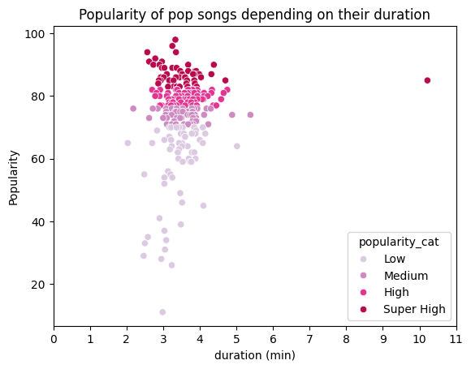

```python
sns.scatterplot(data=pop_df, x="duration", y="popularity", hue="popularity_cat", palette="PuRd")
# Convert x axis ticks from seconds to minutes
ax = plt.gca()
ax.set_xticks(range(0, max(df['duration']) + 1, 60))
ax.xaxis.set_major_formatter(ticker.FuncFormatter(lambda x, _: f"{int(x / 60)}"))

# Add title and axis names
plt.title("Popularity of pop songs depending on their duration")
plt.xlabel("duration (min)")
plt.ylabel("Popularity")

plt.show()
```

💡 It looks like the duration to be prioritized in order to make a popular pop song is around **3 minutes**. Let's take a look at the density of the most popular songs for slices of duration now.

👉 In this case, it would be pertinent to create a "popular_df" that contains our most popular songs.

```python
# Create a smaller DataFrame composed of the most popular songs
popular_df = pop_df[pop_df["popularity_cat"] == "Super High"]
popular_df.reset_index(inplace=True, drop=True)
popular_df.head(3)
```

|  | title | artist | bpm | duration | popularity | popularity_cat |
| --- | --- | --- | --- | --- | --- | --- |
| 0 | Flowers | Miley Cyrus | 118 | 200 | 98 | Super High |
| 1 | BESO | ROSALÍA | 95 | 195 | 96 | Super High |
| 2 | Anti-Hero | Taylor Swift | 97 | 201 | 94 | Super High |

```python
popular_df.shape
```

```
(53, 6)
```

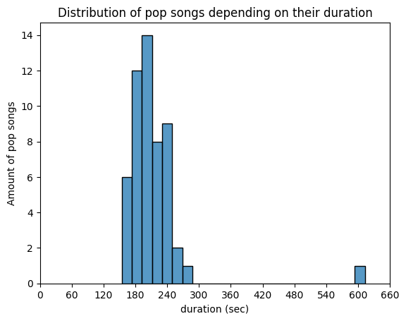

```python
sns.histplot(data=popular_df, x="duration", bins=24)

# Set ticks of 60 seconds on x axis
ax = plt.gca()
ax.set_xticks(range(0, max(df['duration']) + 1, 60))

# Add title and axis labels
plt.title("Distribution of pop songs depending on their duration")
plt.xlabel("duration (sec)")
plt.ylabel("Amount of pop songs")

plt.show()
```

✅ This graph confirms our first thought, the duration to be prioritized while making a popular pop song is a **little more than 3 minutes**.

## 🥁 2. Which tempo should be prioritized ?

Here we are going to compare the popularity of pop songs with their tempo in order to find a correlation between those data.

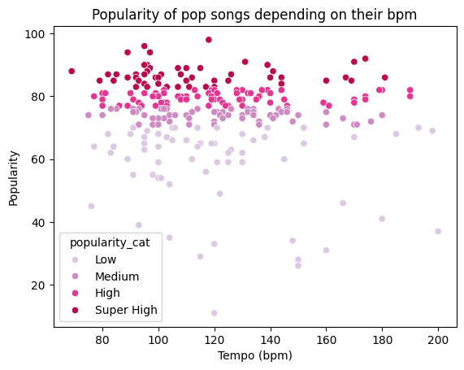

```python
sns.scatterplot(data=pop_df, x="bpm", y="popularity", hue="popularity_cat", palette="PuRd")

# Add title and axis names
plt.title("Popularity of pop songs depending on their bpm")
plt.xlabel("Tempo (bpm)")
plt.ylabel("Popularity")

plt.show()
```

⛔ This graph is not relevant because it looks like the popular songs are scattered all around it. Still, we can observe that there is a higher **density** of dots around 100 bpm.

👉 Our next step is to draw a histogram in order to put a value on that density and identify which bpm are the popular songs composed of.

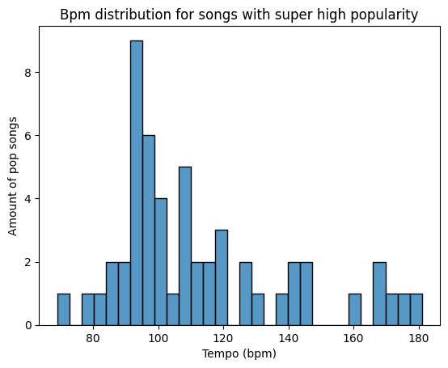

```python
sns.histplot(data=popular_df, x="bpm", stat="count", bins=30)

# Add title and axis names
plt.title("Bpm distribution for songs with super high popularity")
plt.xlabel("Tempo (bpm)")
plt.ylabel("Amount of pop songs")

plt.show()
```

💡 It looks like the popular pop songs have a tempo between 90 and 120 bpm, even though the tempo that is the most present in popular songs is around 95 bpm.

## 3. 🗨️ Which words should be prioritized ?

❗ We have defined a couple of utility functions to make the next blocks easier to read. Let's fetch !

👉 Let's add some preprocessing to our song lyrics before adding them to our DataFrame.

🔎 Let's take a look at our DataFrame now that we have fetched and preprocessed the lyrics of the most popular pop songs.

```python
popular_df.head(3)[["title", "artist", "lyrics"]]
```

|  | title | artist | lyrics |
| --- | --- | --- | --- |
| 0 | Flowers | Miley Cyrus | We were good we were gold Kinda dream that can... |
| 1 | BESO | ROSALÍA | Coro ROSALÍA Ya yo necesito otro beso Uno de ... |
| 2 | Anti-Hero | Taylor Swift | I have this thing where I get older but just n... |

```python
null_lyrics = popular_df["lyrics"].isnull()
print("We were not able to find the lyrics of %.2f%% of our songs." % (null_lyrics.mean() * 100))
```

```
We were not able to find the lyrics of 9.43% of our songs.
```

✅ This looks like a reasonable amount of data for us to delete and continue our study without.

👉 Now we should use the lyrics we managed to get and make a wordcloud to figure out which words are the most used among the most popular songs.

⚠️ For this, we will define as stopwords all the words that are 2-characters long or less, so they don't appear in our wordcloud as they would be too numerous.

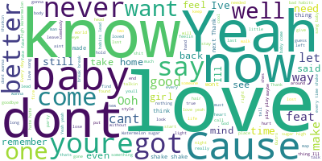

```python
# Get the lyrics that are not null
lyrics = popular_df.loc[popular_df["lyrics"].notnull(), "lyrics"]

# Add the 2-character or less words to the stopwords
stopwords = [*STOPWORDS, *list(filter(lambda x: len(x) <= 2, " ".join(lyrics.values).split(" ")))]

# Generate the wordcloud
wc = WordCloud(stopwords=stopwords)
wc.generate_from_text(text=" ".join(lyrics.values))
wc.background_color = "white"
wc.to_image()
```

💡 What we can conclude from this is that most of the popular songs lyrics are about love. This means that lyrics about **love** should be prioritized while making a popular pop song.

## 📚 Anexes

- You can find the whole notebook on the [GitHub Repository](https://github.com/Lucas-COX/datamining-evaluation/blob/master/notebooks/spotify.ipynb)
- There is also a [pdf version](https://github.com/Lucas-COX/datamining-evaluation/blob/master/spotify.pdf) and [this slides version](https://github.com/Lucas-COX/datamining-evaluation/blob/master/spotify.slides.html).